# NCG612 Assignment1

Olwyn Byrne

12/03/2022

Task: Create a set of Travel to Work Areas using Coombes and Bond algorithm

Travel to Work Areas are a group of localities which have been assigned to a region based on the maximisation of the interactions between them.

We are analysing the TTWA of Dublin to see the population’s relationship with where they live and where they work. We will use an algorithm to break Dublin into regions based on where people live and work. Each region’s size will indicate how many people both live and work in that region. We will set self containment and population parametres to determine how many regions will be created. There will be a trade off between size and self containment.

```r
library("sf")
```

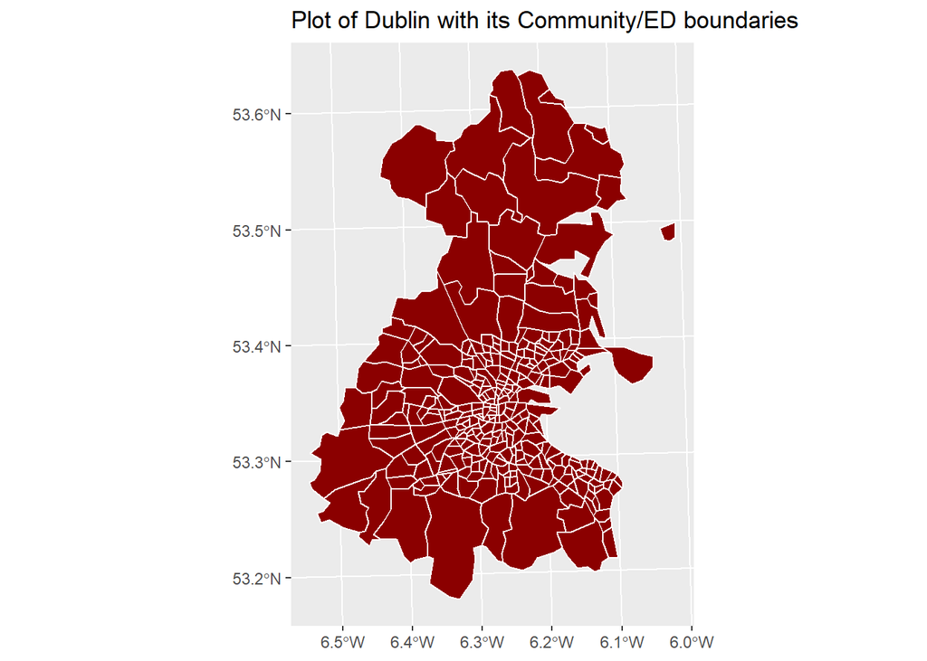

```r
#read in geojson file
dub_eds <- st_read('dub_eds.geojson',quiet=TRUE)

library(ggplot2)
#plot Dublin with its community/ED boundaries
ggplot(dub_eds)+geom_sf(fill='darkred',col='white') + ggtitle('Plot of Dublin with its Community/ED boundaries')
```

```r
library(tidyverse)
#read in dublin trips csv file.
#Shows how many travel from one community to another
dub_trips <- read.csv('dublin_trips.csv')


#Read in lookup table, shows full name per community code
lookup <- read_csv('lookup.csv')
#Join lookup table with dub_eds so full name included
dub_eds<-dub_eds %>%
  left_join(lookup)
```

Use left join to link results of analysis to dub_eds object and create maps.

Total people travelling to each ED:

```r
trips_to_work <- dub_trips %>%
  group_by(community_work)%>%
  summarise(amount=sum(amount))%>%
  rename(community=community_work)



dub_eds <- dub_eds %>%
  left_join(trips_to_work)
```

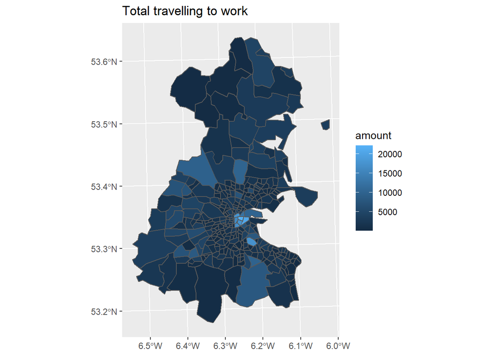

```r
ggplot(dub_eds, aes(fill=amount))+ geom_sf()+ggtitle("Total travelling to work")
```

Brief explanation of the underlying algorithm:

The algorithm joins neighboring areas which satisfy the conditions set, based on community flows. The method uses two properties, self containment and number of people employed. Self containment is the proportion of workers who live and work in an area. We must set minimum and target values as parametres, for both properties, to run the algorithm.

The algorithm checks each area to see if it is over the minimum self containment parametre. If it is not it is assessed against the other neighbouring areas and is joined to the area which has the most important community flows. They are now considered one entity and the joined community flows are recalculated and the algorithm progresses.

Run findClusters function (assignment of travel to work areas)

1. Run algorithm with populations close to 80,000 and 50% self containment

```r
library(LabourMarketAreas)
c1<-findClusters(dub_trips, 15000, 0.4, 80000, 0.5, idcom_type='char')
```

```
## [1] "The algorithm has converged."
```

2. Run algorithm with populations close to 100,000 and 50% self containment

```r
c2<-findClusters(dub_trips, 15000, 0.4, 100000, 0.5, idcom_type='char')
```

```
## [1] "The algorithm has converged."
```

3. Run algorithm with populations close to 80,000 and 60% self containment

```r
c3<-findClusters(dub_trips, 15000, 0.4, 80000, 0.6, idcom_type='char')
```

```
## [1] "The algorithm has converged."
```

4. Run algorithm with populations close to 100,000 and 60% self containment

```r
c4<-findClusters(dub_trips, 15000, 0.4, 100000, 0.6, idcom_type='char')
```

```
## [1] "The algorithm has converged."
```

5. Run algorithm with populations close to 80,000 and 80% self containment

```r
c5<-findClusters(dub_trips, 15000, 0.4, 80000, 0.8, idcom_type='char')
```

```
## [1] "The algorithm has converged."
```

```r
cl_sf <- dub_eds %>%
  left_join( tibble(c1$lma$clusterList) %>%
               mutate(cluster=dub_eds$name[cluster]))
cl_sf$cluster<- as.character(cl_sf$cluster)

library(ggrepel)
lc <- st_centroid(dub_eds) %>%
  st_coordinates()
```

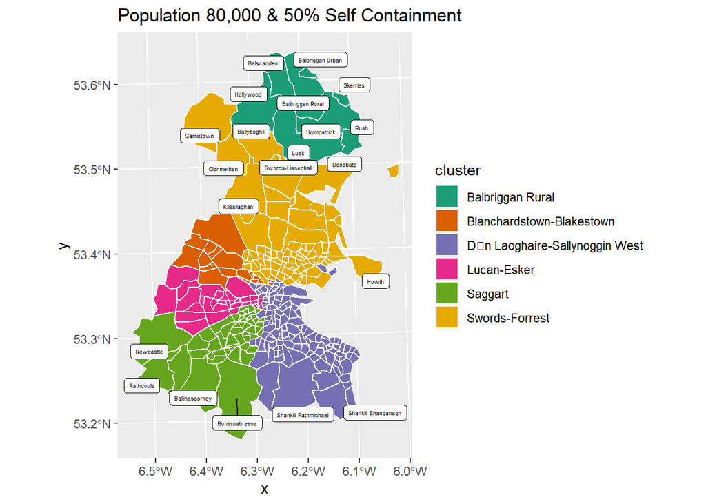

```r
lc <- tibble(x=lc[,1],y=lc[,2],name=dub_eds$name)


ggplot(cl_sf) +geom_sf(col='white',aes(fill=cluster)) +scale_fill_brewer(palette='Dark2') +geom_label_repel(data=lc,mapping=aes(x=x,y=y,label=name),size=1.5)+ggtitle('Population 80,000 & 50% Self Containment')
```

In the first plot we can see TTWAs based on a target working population of 80,000 and 50% self containment.

We can see the Swords-Forrest area is the largest, indicating the least densely populated areas with working people travelling to work in that area. There are rural communities to the north of this area with low populations which would have been joined with communities with stronger work flows closer to the city centre. There may also be less large employment providers in the northern communities in this area.

The Blanchardstown - Blakestown area is the smallest area, followed closely by Lucan-Esker. The communities in these areas have a high population of workers with short travel to work distances. One cause of this could be the high volumes of housing estates and retail/ business parks in close proximity to each other.

In Dun Laoghaire-Sallynoggin West and Saggart the workers are travelling northwards. Dun Laoghaire specifically is influenced by the city centre.

The interesting one is the Balbriggan Rural area, there is a high population of workers who work in the area. I was surprised that this was a smaller area than Swords-Forrest. It would probably be worth exploring the population versus employed population in these areas to see why they performed differently under the algorithm.

There are some areas slightly fragmented which shows non-contiguity. These may need to be fine tuned. A multiple enclave of Dun Laoghaire-Sallynoggin West communities can be seen in the Swords-Forrest area.

There is also one enclave belonging to Blanchardstown- Blakestown and another belonging to Lucan-Esker in Dun Laoghaire - Sallynoggin.

Plot 2nd Example

```r
cl_sf2 <- dub_eds %>%
 left_join( tibble(c2$lma$clusterList) %>%
              mutate(cluster=dub_eds$name[cluster]))
```

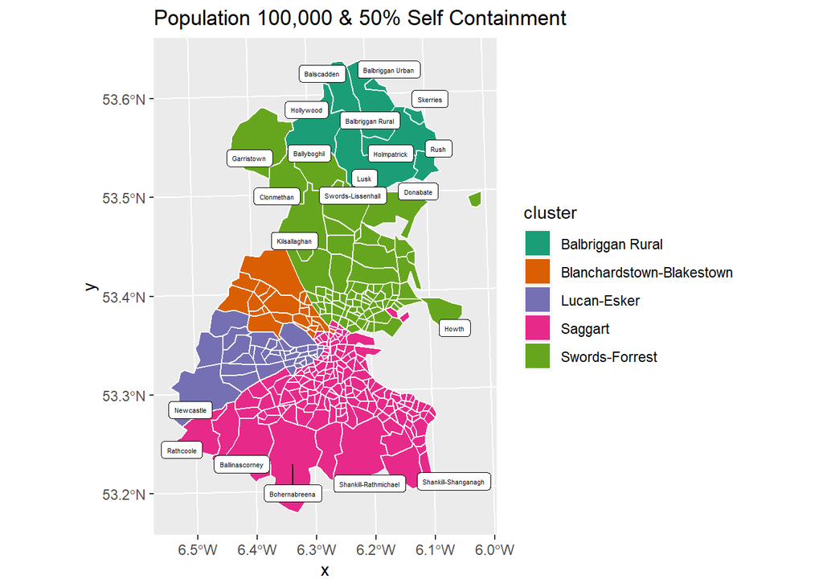

```r
cl_sf2$cluster<- as.character(cl_sf2$cluster)


ggplot(cl_sf2) +geom_sf(col='white',aes(fill=cluster)) +scale_fill_brewer(palette='Dark2') +geom_label_repel(data=lc,mapping=aes(x=x,y=y,label=name),size=1.5)+ggtitle('Population 100,000 & 50% Self Containment')
```

The multiple enclave is still there, the single enclaves seemed to have been remedied and joined their appropriate areas.

Plot 3rd Example:

```r
cl_sf3 <- dub_eds %>%
 left_join( tibble(c3$lma$clusterList) %>%
               mutate(cluster=dub_eds$name[cluster]))
```

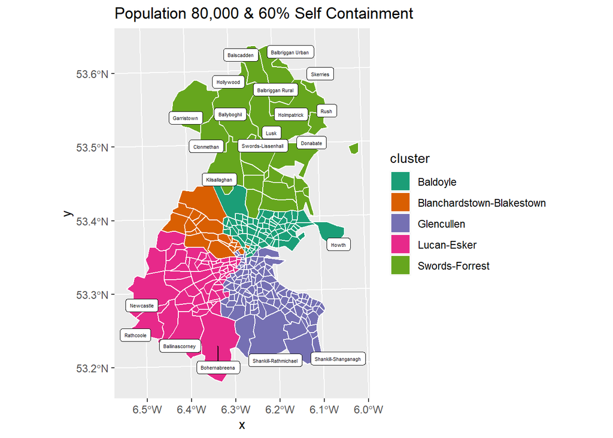

```r
cl_sf3$cluster<- as.character(cl_sf3$cluster)


ggplot(cl_sf3) +geom_sf(col='white',aes(fill=cluster)) +scale_fill_brewer(palette='Dark2') +geom_label_repel(data=lc,mapping=aes(x=x,y=y,label=name),size=1.5)+ggtitle('Population 80,000 & 60% Self Containment')
```

In this plot we have kept population at 80,000 but raised the self containment target to 60%. Again the clusters have reduced to five. But the north of the county looks different. Ballbriggan Rural has combined with Swords-Forrest.

Saggart and Lucan-Esker have also combined. Swords & Lucan have the predominant work flows so there must be more people employed and working in these areas than the areas previously known as Ballbriggan Rural and Saggart.

There is a new area called Baldoyle. This is a small area near the city centre, which indicate a high population of employed people working in and around the city centre.

There is a single enclave belonging to Blanchardstown-Blakestown which appears in Baldoyle’s area.

Plot 4th Example

```r
cl_sf4 <- dub_eds %>%
  left_join( tibble(c4$lma$clusterList) %>%
               mutate(cluster=dub_eds$name[cluster]))
```

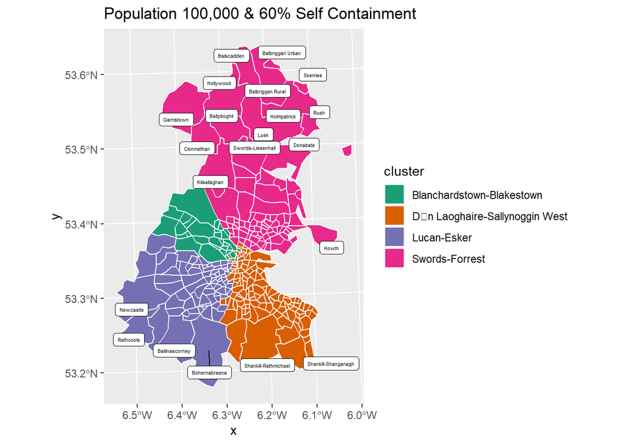

```r
cl_sf4$cluster<- as.character(cl_sf4$cluster)


ggplot(cl_sf4) +geom_sf(col='white',aes(fill=cluster)) +scale_fill_brewer(palette='Dark2') +geom_label_repel(data=lc,mapping=aes(x=x,y=y,label=name),size=1.5)+ggtitle('Population 100,000 & 60% Self Containment')
```

In this example we have increased the employed population to 100,000 and Self Containment to 60%. So our targets are high. This results in four clusters as each cluster is targeting a larger population. Swords-Forrest has grown significantly and encompasses approximately half the county.

Lucan-Esker and Saggart have combined, again Lucan-Esker was the predominant area of the two.

It looks like no fine tuning is required.

Plot 5th Example:

```r
cl_sf5 <- dub_eds %>%
 left_join( tibble(c5$lma$clusterList) %>%
               mutate(cluster=dub_eds$name[cluster]))
```

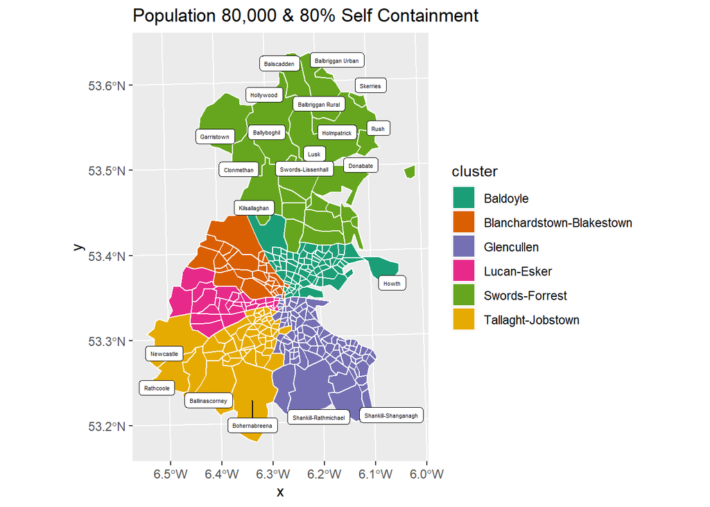

```r
cl_sf5$cluster<- as.character(cl_sf5$cluster)


ggplot(cl_sf5) +geom_sf(col='white',aes(fill=cluster)) +scale_fill_brewer(palette='Dark2') +geom_label_repel(data=lc,mapping=aes(x=x,y=y,label=name),size=1.5)+ggtitle('Population 80,000 & 80% Self Containment')
```

In the 5th example we have left population at 80,000 but increased self containment to 80%. We are back to six clusters. This proves population has a bigger impact on the number of clusters created than self containment does.

The biggest changes are in the north of the county. Swords-Forrest has changed, It has taken more rural communities and less of the communities closer to the city centre.

Provide brief discussion of result:

Throughout all the examples, the Blanchardstown-Blakestown area has barely changed. It has stayed pretty consistent through all the parametre changes. This indicates, to me, a large population of employed people, who work in the area, evenly distributed through all the communities in the area.

The city centre has an influential pull on the areas to the south of the county, meaning many people living in the south county work in the city centre. The west of the county is more self-contained.

The areas to the north of the county changed the most dramatically when the parametres changed. There is a lot of rural communities and depending on target sizes these were pulled in different directions. The bigger the target population the bigger the areas in the north got.

The bigger the target population the less clusters created. Self containment has a lesser influence.